# STAN tutorial

# Introduction

By now we are familiar with the overall concept of probabilistic programing languages and the fundamental building blocks of STAN.

In this tutorial we will run a small bayesian linear regression example using STAN. We will cover:

- loading data and formatting it
- defining a STAN model
- running inference
- evalauting the sampling process
- visualizing the model

# Installing packages

Please run this chunk manually before turning to the rest of the notebook. This might take some time to install.

```r
install.packages("rstan")
install.packages("tidyverse")

install.packages("bayesplot")
install.packages("tidybayes")
install.packages("modelr")
install.packages("brms")
```

# Preparing data for STAN

If in doubt, the best way to store data in R is in a dataframe. For the purpose of this tutorial we will load a small dataset from within the R language.

First, let’s load some packages.

```r
library(tidyverse) #"tidy" philosophy of data manipulation in R
library(rstan) # stan interface
```

Let’s prepare our data and take a look at it.

```r
df <- mtcars %>%
  rownames_to_column("name")

df
```

| name | mpg | cyl | disp | hp | drat | wt | qsec | vs | am | gear | carb |
| --- | --- | --- | --- | --- | --- | --- | --- | --- | --- | --- | --- |
| Mazda RX4 | 21.0 | 6 | 160.0 | 110 | 3.90 | 2.620 | 16.46 | 0 | 1 | 4 | 4 |
| Mazda RX4 Wag | 21.0 | 6 | 160.0 | 110 | 3.90 | 2.875 | 17.02 | 0 | 1 | 4 | 4 |
| Datsun 710 | 22.8 | 4 | 108.0 | 93 | 3.85 | 2.320 | 18.61 | 1 | 1 | 4 | 1 |
| Hornet 4 Drive | 21.4 | 6 | 258.0 | 110 | 3.08 | 3.215 | 19.44 | 1 | 0 | 3 | 1 |
| Hornet Sportabout | 18.7 | 8 | 360.0 | 175 | 3.15 | 3.440 | 17.02 | 0 | 0 | 3 | 2 |
| Valiant | 18.1 | 6 | 225.0 | 105 | 2.76 | 3.460 | 20.22 | 1 | 0 | 3 | 1 |
| Duster 360 | 14.3 | 8 | 360.0 | 245 | 3.21 | 3.570 | 15.84 | 0 | 0 | 3 | 4 |
| Merc 240D | 24.4 | 4 | 146.7 | 62 | 3.69 | 3.190 | 20.00 | 1 | 0 | 4 | 2 |
| Merc 230 | 22.8 | 4 | 140.8 | 95 | 3.92 | 3.150 | 22.90 | 1 | 0 | 4 | 2 |
| Merc 280 | 19.2 | 6 | 167.6 | 123 | 3.92 | 3.440 | 18.30 | 1 | 0 | 4 | 4 |

[output cut: 22 more lines]

# Defining a STAN model

## The effect of weight and cylinders on fuel efficiency?

Next, we want to predict the fuel efficency of cars in our dataset as a function of the cars weight and the number of cylinders in the car’s engine.

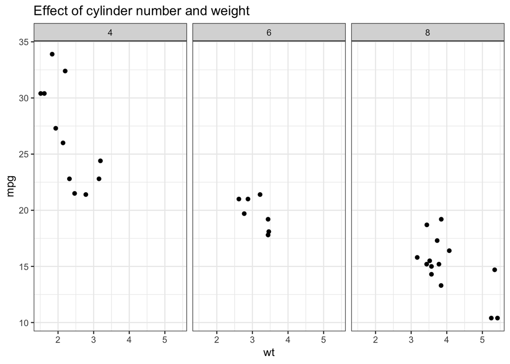

```r
df %>%
  ggplot(aes(wt, mpg)) +
  geom_point() +
  theme_bw() +
  facet_grid(~ cyl) +
  labs(title = "Effect of cylinder number and weight")
```

We can fit a multivariate linear regression to this data.

```r
model <- lm(mpg ~ wt + cyl, data = df)

summary(model)
```

```
##
## Call:
## lm(formula = mpg ~ wt + cyl, data = df)
##
## Residuals:
##     Min      1Q  Median      3Q     Max
## -4.2893 -1.5512 -0.4684  1.5743  6.1004
##
## Coefficients:
##             Estimate Std. Error t value Pr(>|t|)
## (Intercept)  39.6863     1.7150  23.141  < 2e-16 ***
## wt           -3.1910     0.7569  -4.216 0.000222 ***
## cyl          -1.5078     0.4147  -3.636 0.001064 **
## ---
## Signif. codes:  0 '***' 0.001 '**' 0.01 '*' 0.05 '.' 0.1 ' ' 1
##
## Residual standard error: 2.568 on 29 degrees of freedom
## Multiple R-squared:  0.8302, Adjusted R-squared:  0.8185
## F-statistic: 70.91 on 2 and 29 DF,  p-value: 6.809e-12
```

## Switching to STAN

Next, we can start the model compilation from within R.

```r
model_stan <- stan("mtcars.stan",
                   data = list(N=nrow(df),
                               mpg = df$mpg,
                               wt = df$wt,
                               cyl = df$cyl),
                   iter = 1000)
model_stan_summary <- summary(model_stan)
model_stan_summary$summary
```

```
##             mean    se_mean        sd       2.5%        25%        50%
## alpha  39.714490 0.06040373 1.8683576  35.966931  38.430421  39.755987
## beta   -3.207145 0.02727101 0.7950106  -4.846259  -3.705315  -3.205938
## gamma  -1.502382 0.01477419 0.4383693  -2.333298  -1.795279  -1.511506
## sigma   2.691572 0.01163268 0.3784476   2.086365   2.418656   2.648926
## lp__  -45.881476 0.06112528 1.5661257 -49.915563 -46.580222 -45.548671
##              75%       97.5%     n_eff      Rhat
## alpha  41.018876  43.3507437  956.7369 1.0004827
## beta   -2.682709  -1.6353932  849.8520 1.0010068
## gamma  -1.221808  -0.5847768  880.3855 0.9996608
## sigma   2.922327   3.5203413 1058.4056 1.0046913
## lp__  -44.758617 -43.9339695  656.4648 1.0033113
```

Per default, STAN uses 50% of the scheduled iterations per chain for warmup. The summary file gives an overview about the estimated values for the parameters and the probability intervals.

Next to the model parameters, we also estimated the error term sigma.

The following elements of the table deserve additional explanation. * *lp_* a scaled version of the sum of log-likelihoods across the dataset. According to the original paper it is the “log density up to a constant”. * *n_eff* is the effective sample size. This metric estimates the number of random (non-correlated) samples that would approximately render the same estimate. * *Rhat* is the potential scale reduction factor on split chains (at convergence, we expect R_hat=1). In our example, the Markov chains for all parameters converged. If multiple Markov chains, do not converge to the same posterior estimate, the key assumptions of *ergodicity* may not be fulfilled. This could be due to an unfavorable geometry of our posterior distribution.

Per default, we run 4 MCMC chains to estimate the model parameters.

# Visualization

Let’s visualize the model’s parameters first. We load a dedicated package for visualization STAN based models in R.

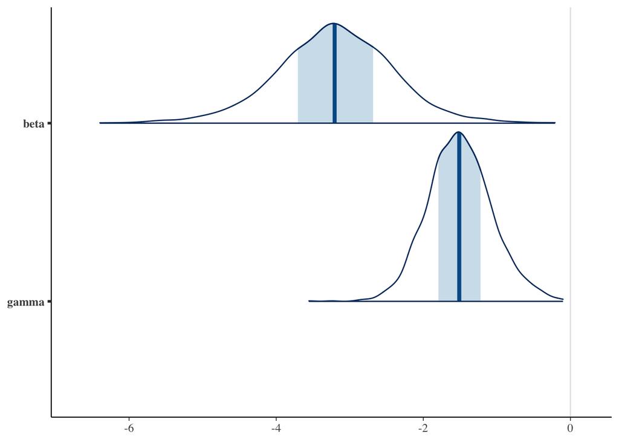

```r
library(bayesplot)
posterior <- as.matrix(model_stan)

mcmc_areas(posterior,
           pars = c("beta", "gamma"))
```

In order to come back to our initial plot of the data we wanted to model, we are loading another set of more recent STAN based packages.

We redefine our model, create a matrix of X values that we use to run inference on and finally sample 100 parameters from our model. Finally, we plot the 100 model estimates next to our data.

```r
library(tidybayes)
library(modelr)
library(brms)
m_mpg_am = brm(mpg ~ wt + cyl, data = mtcars)
```

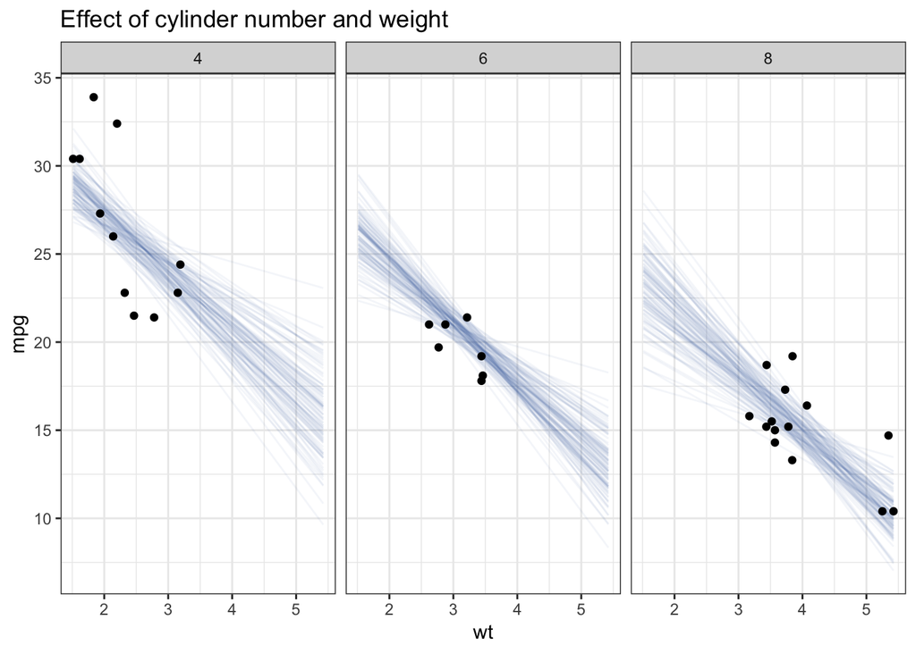

```r
mtcars %>%
  data_grid(wt = seq_range(wt, n = 200), cyl) %>%
  add_fitted_draws(m_mpg_am, n = 100) %>%
 # sample 100 fits from the posterior
  ggplot(aes(x = wt, y = mpg)) +
  geom_line(aes(y = .value, group = .draw), alpha = 1/20, color = "#08519C") +
  geom_point(data = mtcars) +
  theme_bw() +
  facet_grid(~ cyl) +
  labs(title = "Effect of cylinder number and weight")
```